# How to Reshape Conjoint Data

AS d’Urso

November 2, 2019

## Overview

This document serves as a tutorial for how to take survey data (from Qualtrics, for example) and reshape it to be compatible with `cjoint`. This tutorial uses simulated data taken from an experiment by S.R. Gubitz.

## Set-up

### Load Packages

```r
## Load packages
library(tidyverse)
library(cjoint)
```

### Load Data

I have also included the data for those who wish to follow along on their computer.

```r
srg_dat <- read_csv("Gubitz simulated data.csv")
```

### Renaming Variables

**NOTE**: In this case, the variables in this dataset are already recoded according to the abovementioned coding scheme.  
To aid the reshaping process, it helps to recode the data columns using a systematic naming convention. I have found that the best convention is as follows: `variablename_taskiteration_index`. Take, for example, education of a candidate in a hypothetical conjoint design. For each task, we would code the variable as: `education_1`, `education_2`, `education_3`, until the last task.  
This coding scheme should also be used for respondent *answers* in each task iteration. For instance, if the respondent is asked to pick between two candidates, this variable should be coded: `choice_1`, `choice_2`, `choice_3`, until the last task.  
If the respondent is answering a *battery* of questions related to the candidate for each iteration, this variable can be captured in the `index` portion of the `variablename_taskiteration_index` scheme. For instance, if the respondent is asked in each iteration three questions on the leadership qualities of a candidate, this should be coded: `leadership_1_1`, `leadership_1_2`, `leadership_1_3`, for the first iteration. In the second iteration, it would be, `leadership_2_1`, `leadership_2_2`, and `leadership_2_3`. This pattern continues until the last iteration.  
It does not matter if one decides to recode the variables using this scheme on the actual survey (i.e. in Qualtrics) or in R (the `rename` function works well). *However, renaming variables in the following format is essential for the following reshaping process.*

## Reshaping Data

The logic of reshaping is as follows:

1. First, we take the data, which is in wide format, and `gather` based on the conjoint task-specific variables into long format. Because of our coding scheme, we have indicated each task using an underscore and then numbering the task. This conjoint experiment has six iterative task; thus, we are aiming for 6 rows per respondent (that is, one row per task).
   1. Code: `gather(key = task, value = score, contains("_1"), contains("_2"), contains("_3"), contains("_4"), contains("_5"), contains("_6"))`
2. Next, we separate each variable into three variables: the variable name, the iteration, and the index. Even if most variables do not have an index, we still need to do this to capture variables which have an index (see “Renaming Variables” for more details on this).
   2. Code: `separate(task, c("variable", "iteration", "index"))`
3. Once we separate, we can create a variable for when there is an index present or not.
   3. Code: `mutate(index = ifelse(is.na(index), "", index))`
4. Then we can `unite` the `variable` and `index` columns to make a new variable, which is named as the variable and the index number. This way, we can later easily access the battery.
   4. Code: `unite("variable_index", c("variable", "index"), sep = "")`
5. Finally, we wish to spread the variable name is its own column, and each row for those columns contains the values of that variable.
   5. Code: `spread(key = variable_index, value = score)`

```r
srg_reshape <- srg_dat %>%
  #first step is gathering all the variables that we want to use as our attributes;
  #because we have named each task iteration in this format, using contains will get each conjoint-related variable
  gather(key = task, value = score, contains("_1"), contains("_2"), contains("_3"), contains("_4"), contains("_5"), contains("_6")) %>%
  #we need to separate these variables out by characteristics; this can be done using `separate`, because variable were meaningfully named using underscores
  separate(task, c("variable", "iteration", "index")) %>%
  #creating an indicator of variables that were a part of an index
  mutate(index = ifelse(is.na(index), "", index))  %>%
  #create a variable specific column
  unite("variable_index", c("variable", "index"), sep = "") %>%
  #spreading out the variables so that each meaningful variable (or attribute) is a column
  spread(key = variable_index, value = score) %>%
  #lastly, because the data are a mix of upper and lower case, I use clean_names to make the variables names follow a uniform convention (this is optional, but recommended)
  janitor::clean_names()
```

### Checking the reshaped data

As mentioned, there were six tasks in the Gubitz experiment. This means that for each respondent, we should now have six rows.

```r
srg_reshape %>% filter(response_id == "R_1Ibe8eFUzu8FGJf") %>% select(1:3)
```

```
## # A tibble: 6 x 3
##   start_date      end_date        status
##   <chr>           <chr>            <dbl>
## 1 10/1/2019 12:54 10/1/2019 12:54      2
## 2 10/1/2019 12:54 10/1/2019 12:54      2
## 3 10/1/2019 12:54 10/1/2019 12:54      2
## 4 10/1/2019 12:54 10/1/2019 12:54      2
## 5 10/1/2019 12:54 10/1/2019 12:54      2
## 6 10/1/2019 12:54 10/1/2019 12:54      2
```

## AMCEs

We can now use our reshaped data for our AMCEs

### Cleaning Data

In order to calculate AMCEs, we must make sure our data are properly cleaned. We must make sure that our outcome of interest–here it is `news`–is an integer and does not have any missing values. We also much make sure our predictors of interest, are factor variables.

```r
srg_clean <- srg_reshape %>%
  #first, we want to make sure our outcome of interest is a numeric variable
  mutate(news = as.numeric(news)) %>%
  #next, we want to make sure our predictors of interest are factors
  mutate_if(is.character, as.factor) %>%
  #lastly, we want to make sure our outcome of interest has no missing values (either by filtering them out, or through MI, etc...)
  filter(!is.na(news))
```

### Plot AMCEs

Now we can plot our AMCEs. Remember that these results are meaningless, because this is simulated data.

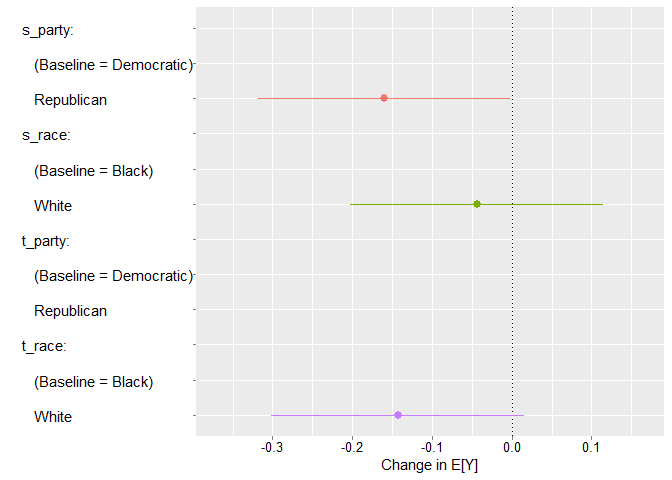

```r
srg_clean %>%
  amce(formula = news ~ s_party + t_party + s_race + t_race) %>%
  plot()
```